# 短文本情感分析任务

**任务描述**： 基于机器学习方法实现电影评论文本的情感分类。 最终机器能够从大规模标注文本中获得经验，判定某一指定文本的情感极性：正面/负面

**数据集**： 数据集已经切分为训练集和测试集， 其中训练集 25000 条， 测试集 25000 条；训练集和测试集中正面（positive） 评价和负面（negtive）评价各占一半。

**目录结构如下**：训练集和测试集分别位于 train 和 test 两个目录，每个目录下均有 pos 和 neg 两个子目录，分别代表正面评价的文本和负面评价的文本；每一个训练样例一个文件，文本命名方式为： id_rating.txt，其中 id 为样例唯一 id， rating 为该文本的情感极性评分，正面评价为 7-10分，负面评价为 0-4 分； 例如： [test/pos/200_8.txt]， 表示测试集中 id 为 200、评分为 8 的正面评价实例（正例）

**提示**：

1. 本任务为典型的文本分类问题（正面/负面两类分类问题）；
2. 可以充分使用目前流行的大规模预训练语言模型如 BERT 等； 注意分词问题（tokenization）；
3. 虽然是两类分类问题，是否可以借鉴训练样例中给出的 rating 值来辅 助训练过程；
4. 从训练集中要独立切分出部分训练例作为验证集来调整模型的超参 数；
5. 模型构造时注意输入字符串序列的最大长度限制；
6. 如果设计的分类器性能不好，是否可以考虑集成学习？ (Adaboost)；
7. 充分发挥自己的动手能力，提升模型的测试效果~

# （1）朴素贝叶斯实现

## V1.1 二分类实现

```python
import os
import re

def findFile(path):
    for file in os.listdir(path):
    #for file in os.listdir(path)[:1000]:
        if file.endswith(".txt"):
            #print(file)
            yield os.path.join(path, file)

def create(path):
    ans = []
    com_cnt = 0
    err_cnt = 0
    for file in findFile(path):
        with open(file, "r", encoding='UTF-8') as f:
            try:
                tmp = re.split(' ', f.read())
                ans.append([i for i in tmp if i])
                com_cnt += 1
            except:
                err_cnt += 1
    print("正确读取文件:{}   错误读取文件:{}".format(com_cnt, err_cnt))
    return ans

neg = create(r"dataset\train\neg")
pos = create(r"dataset\train\pos")
data = [row + [0] for row in neg] + [row + [1] for row in pos]

testn = create(r"dataset\test\neg")
testp = create(r"dataset\test\pos")
```

```
正确读取文件:12500   错误读取文件:0
正确读取文件:12500   错误读取文件:0
正确读取文件:12500   错误读取文件:0
正确读取文件:12500   错误读取文件:0
```

```python
class Bayes:                                    #改用的机器学习课写的贝叶斯，没用那个矩阵
    def __init__(self):
        self.y_label = {}                       # pos例子的字典, key:word, val:count
        self.n_label = {}                       # neg例子的字典
        self.n0 = 0
        self.n1 = 0
    def fit(self,data):
        for row in data:
            if row[-1]:                         #pos文本
                self.n1 +=1
                for i,d in enumerate(row[:-1]):
                    if d not in self.y_label:
                        self.y_label[d] = 1
                    else: self.y_label[d] += 1
            else:
                self.n0 +=1
                for i,d in enumerate(row[:-1]):
                    if d not in self.n_label:
                        self.n_label[d] = 1
                    else: self.n_label[d] += 1

    def predict(self,data):
        p_yes = self.n1/(self.n0 + self.n1)
        p_no = self.n0/(self.n0 + self.n1)
        for d in data:
            p_yes *= (self.y_label.get(d, 0)+2)/(self.n1+2)          #拉普拉斯平滑，即加 1 平滑
            p_no *= (self.n_label.get(d, 0)+2)/(self.n0+2)

        #print("p(yes):", p_yes)
        #print("p(no):", p_no)
        return True if  p_yes >= p_no else False
```

```python
model = Bayes()
model.fit(data)

tp, fp, tn, fn = 0, 0, 0, 0
for t in testp:
    if model.predict(t):
        tp += 1
    else: fn += 1
for t in testn:
    if model.predict(t):
        fp += 1
    else: tn += 1

print("正确率：{}".format((tp+tn)/(tp+fp+tn+fn)))
print("准确率：{}".format(tp/(tp+fp)))
```

```
正确率：0.77656
准确率：0.7312683971099813
```

## 分数记录：

| 平滑 | 正确率 | 准确率 |
| --- | --- | --- |
| 未平滑 | 0.51324 | 0.5067958773046441 |
| +1 | 0.77308 | 0.7278552833589212 |
| +2 | 0.77656 | 0.7312683971099813 |

## V1.2 引入TF-IDF特征提取，及停用词

```python
import os
import re
from sklearn.feature_extraction.text import TfidfVectorizer

def findFile(path):
    for file in os.listdir(path):
        if file.endswith(".txt"):
            yield os.path.join(path, file)

def create(path):
    ans = []
    for file in findFile(path):
        vectorizer = TfidfVectorizer(stop_words = "english")
        with open(file, "r", encoding='UTF-8') as f:
            tmp = f.read().split('.')
            vectorizer.fit(tmp)
        ans.append(vectorizer.get_feature_names())
    return ans


neg = create(r"dataset\train\neg")
pos = create(r"dataset\train\pos")
data = [row + [0] for row in neg] + [row + [1] for row in pos]

testn = create(r"dataset\test\neg")
testp = create(r"dataset\test\pos")
```

```python
class Bayes:                                    #改用的机器学习课写的贝叶斯，没用那个矩阵
    def __init__(self):
        self.y_label = {}                       # pos例子的字典, key:word, val:count
        self.n_label = {}                       # neg例子的字典
        self.n0 = 0
        self.n1 = 0
    def fit(self,data):
        for row in data:
            if row[-1]:                         #pos文本
                self.n1 +=1
                for i,d in enumerate(row[:-1]):
                    if d not in self.y_label:
                        self.y_label[d] = 1
                    else: self.y_label[d] += 1
            else:
                self.n0 +=1
                for i,d in enumerate(row[:-1]):
                    if d not in self.n_label:
                        self.n_label[d] = 1
                    else: self.n_label[d] += 1

    def predict(self,data):
        p_yes = self.n1/(self.n0 + self.n1)
        p_no = self.n0/(self.n0 + self.n1)
        for d in data:
            p_yes *= (self.y_label.get(d, 0)+200)/(self.n1+2)          #拉普拉斯平滑，即加 1 平滑
            p_no *= (self.n_label.get(d, 0)+200)/(self.n0+2)

        #print("p(yes):", p_yes)
        #print("p(no):", p_no)
        return True if  p_yes >= p_no else False
```

```python
model = Bayes()
model.fit(data)
tp, fp, tn, fn = 0, 0, 0, 0
for t in testp:
    if model.predict(t):
        tp += 1
    else: fn += 1
for t in testn:
    if model.predict(t):
        fp += 1
    else: tn += 1

print("正确率：{}".format((tp+tn)/(tp+fp+tn+fn)))
print("准确率：{}".format(tp/(tp+fp)))
```

```
正确率：0.8314
准确率：0.8420444224258938
```

[output not shown]

## V1.3 对 1.2 测算平滑参数的影响

对1.2的文本处理模块不变，改写模型及评测

```python
class Bayes:                                    #改用的机器学习课写的贝叶斯，没用那个矩阵
    def __init__(self):
        self.y_label = {}                       # pos例子的字典, key:word, val:count
        self.n_label = {}                       # neg例子的字典
        self.n0 = 0
        self.n1 = 0
    def fit(self,data):
        for row in data:
            if row[-1]:                         #pos文本
                self.n1 +=1
                for i,d in enumerate(row[:-1]):
                    if d not in self.y_label:
                        self.y_label[d] = 1
                    else: self.y_label[d] += 1
            else:
                self.n0 +=1
                for i,d in enumerate(row[:-1]):
                    if d not in self.n_label:
                        self.n_label[d] = 1
                    else: self.n_label[d] += 1

    def predict(self,data,x):
        p_yes = self.n1/(self.n0 + self.n1)
        p_no = self.n0/(self.n0 + self.n1)
        for d in data:
            p_yes *= (self.y_label.get(d, 0) + x)/(self.n1+2)          #拉普拉斯平滑，即加 1 平滑
            p_no *= (self.n_label.get(d, 0) + x)/(self.n0+2)

        #print("p(yes):", p_yes)
        #print("p(no):", p_no)
        return True if  p_yes >= p_no else False
```

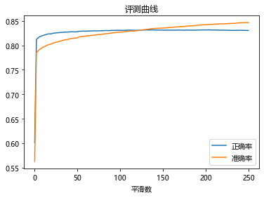

```
程序运行了：196.99278736114502
```

```python
import numpy as np
import matplotlib.pyplot as plt
import time

start_time = time.time()

#解决中文乱码问题
plt.rcParams['font.family']=['Microsoft YaHei']
model = Bayes()
model.fit(data)

def main(arr):

    x, acc, pre = [], [], []

    for i in arr:

        tp, fp, tn, fn = 0, 0, 0, 0
        for t in testp:
            if model.predict(t, i):
                tp += 1
            else: fn += 1
        for t in testn:
            if model.predict(t, i):
                fp += 1
            else: tn += 1

        x.append(i)
        acc.append((tp+tn)/(tp+fp+tn+fn))
        pre.append(tp/(tp+fp))

    plt.plot(x, acc, label='正确率')
    plt.plot(x, pre, label='准确率')

    plt.title("评测曲线")
    plt.xlabel('平滑数')
    plt.legend()
    plt.show()

    return acc, pre

acc,pre = main([i for i in range(0,251,2)])

end_time = time.time()
print("程序运行了：{}".format(end_time-start_time))

# for x,y in zip(acc,pre):
#     print(x,y)
# 暂时选取 200 为最优
```

参考资料：

- https://scikit-learn.org/stable/modules/generated/sklearn.feature_extraction.text.TfidfVectorizer.html

## V2.0 使用sklearn的多项式贝叶斯

## test_demo

```python
import os
import re
from sklearn.feature_extraction.text import TfidfVectorizer
from sklearn.naive_bayes import MultinomialNB

def findFile(path):
    for file in os.listdir(path):
        if file.endswith(".txt"):
            yield os.path.join(path, file)

def create(path):
    ans = []
    for file in findFile(path):
        with open(file, "r", encoding='UTF-8') as f:
            ans.append(str(f.read()))
    return ans                                  #ans中，一篇文章的整个字符为一项

vectorizer = TfidfVectorizer(stop_words = "english")

neg = create(r"dataset\train\neg")
pos = create(r"dataset\train\pos")
testn = create(r"dataset\test\neg")
testp = create(r"dataset\test\pos")

train = vectorizer.fit_transform(neg+pos)
test = vectorizer.transform(testn+testp)

model = MultinomialNB()
model.fit(train, [0]*12500+[1]*12500)
print("准确率为:",model.score(test, [0]*12500+[1]*12500))
```

```
准确率为: 0.82992
```

## 这是一个示例代码

```python
from sklearn.datasets import fetch_20newsgroups
from sklearn.naive_bayes import MultinomialNB # 多项式模型，进行文本分类
from pprint import pprint        #data pretty printer
from sklearn.feature_extraction.text import TfidfVectorizer #TF-IDF文本特征提取

newsgroups_train = fetch_20newsgroups(subset='train')

#pprint(list(newsgroups_train.target_names))

select = ['alt.atheism','comp.graphics','misc.forsale','rec.autos',
          'sci.crypt','soc.religion.christian','talk.politics.guns']

train=fetch_20newsgroups(subset='train',categories=select)   # 1.数据集导入

#print(type(train),dir(train))                         #这是一些 python自省函数 ！！！！！！！！！！
print(type(train.data),dir(train.data))
print(train.data[:1])
#print(train.target)
test=fetch_20newsgroups(subset='test',categories=select)


vectorizer = TfidfVectorizer()
train_v=vectorizer.fit_transform(train.data)                 # 2.文本特征向量化
test_v=vectorizer.transform(test.data)

model = MultinomialNB()
model.fit(train_v,train.target)                              # 3.训练模型
print("准确率为:",model.score(test_v,test.target))
```

[output not shown]

## 查看环境版本

```python
import numpy
import sys
print(sys.version)
print(numpy.__version__)
```

```
3.8.5 (default, Sep  3 2020, 21:29:08) [MSC v.1916 64 bit (AMD64)]
1.19.2
```